# Communicate Data Findings: 2019 Ford Go-Bike Project

### Udacity DataAnalysis NanoDegree October, 2022.

### Prepared By: Alagbe Oluwapelumi Olaoluwa

## Investigation Overview

> In this investigation, I will go deeper on the 2019 dataset and focus my study on the riders basic data(characteristics) which includes gender, age, user type, location and their effect on the biking duration. Also, I will investiage the bikers the preferred hour of the day and day of the week for bikers.

## Dataset Overview

> The data consisted of prices and attributes of approximately 180,500 trips. The attributes included the characterstics such as : duration_sec, start_time, end_time, user_type, start_station_name and end_station_name. Eight thousand three hundred and sixteen data points were removed from the analysis due to inconsistencies or missing information.

### Distribution of Users : Subscribers/Customers

#### This slide establishes the fact that a vast majority of users are Subscribers rather than normal customers.

```
(-1.1073438004106799,
 1.1072112401416903,
 -1.1054115374334084,
 1.1091435031189618)
```

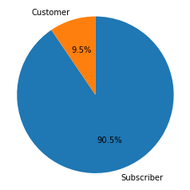

### Distribution of Gender: Male/Female

#### This slide establishes the fact that a vast majority of users are Male(128546) rather than Female(40128) and Other with 3595

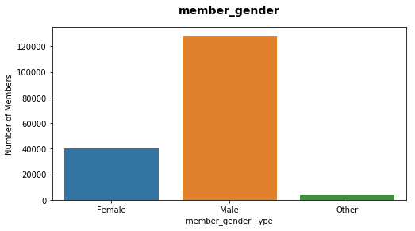

### Distribution of Age: Memeber Age

#### This slide establishes the fact that a vast majority of users are between 18 to 50 years old.

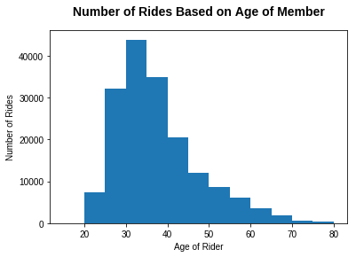

### Distribution of Location : Top 10 start station location

#### Market St at 10th St is rank first where users start their trip.

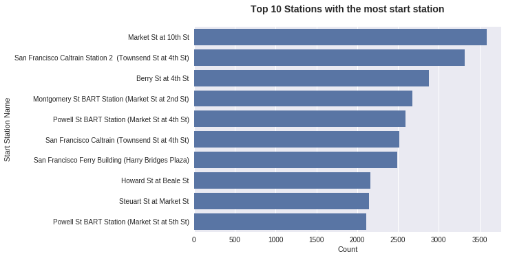

### Distribution of user type, gender on the top 10 locations

#### subscribers are more than customers in each station and likewise the trips for male riders are way more than in females.

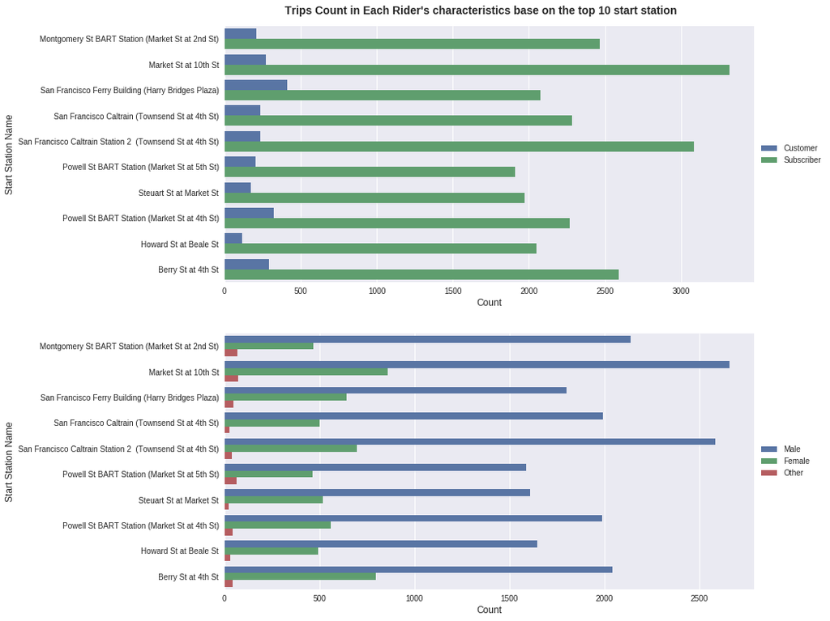

## Distribution of how the top 10 start station name users start their ride during the hour of the day.

#### The slide below shows that bigger number of users prefer ride bike in the morning at 8 am.

#### Also, people in San Francisco Caltrain Station 2 (Townsend St at 4th St) start most of the rides at 8 am.

[figure not shown]

## Distribution of duration in which user ride.

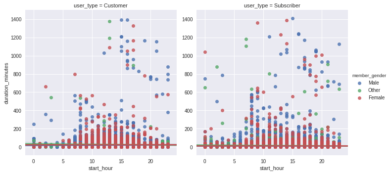